[figure not shown]

# Task 3 Nesting Framework Analysis

#### *Development and Validation of Spatial Covariates for Inputs to Deforestation Risk Modelling*

- Introduction
- Import data
  - AOI Jurisdiction
  - Built Environment
  - Transportation
  - Hydrography
  - Topography
- Risk-allocated deforestation
- Stratification of deforestation pixels

### Introduction

The following spatial covariates were imported as potential drivers of deforestation risk. Covariates were merged between demographic and geographic datasets surrounding the project area and national level datasets beyond the project area in order to enable jurisdictional analysis.

### Import data

#### AOI Jurisdiction

```r
library(geodata)
library(tmaptools)
library(tmap)
library(sf)

# AOI Jurisdictional Bdry
aoi_country = geodata::gadm(country="ECU", level=0, path="./03_Spatial_Data/AOI") |> sf::st_as_sf()
aoi_states  = geodata::gadm(country="ECU", level=1, path="./03_Spatial_Data/AOI") |> sf::st_as_sf()
st_write(aoi_country, "./03_Spatial_Data/AOI/aoi_country.shp", delete_dsn = T)
st_write(aoi_states, "./03_Spatial_Data/AOI/aoi_states.shp", delete_dsn = T)
```

```
Deleting source `./03_Spatial_Data/AOI/aoi_country.shp' using driver `ESRI Shapefile'
Writing layer `aoi_country' to data source
  `./03_Spatial_Data/AOI/aoi_country.shp' using driver `ESRI Shapefile'
Writing 1 features with 2 fields and geometry type Multi Polygon.
```

```
Deleting source `./03_Spatial_Data/AOI/aoi_states.shp' using driver `ESRI Shapefile'
Writing layer `aoi_states' to data source
  `./03_Spatial_Data/AOI/aoi_states.shp' using driver `ESRI Shapefile'
Writing 24 features with 11 fields and geometry type Unknown (any).
```

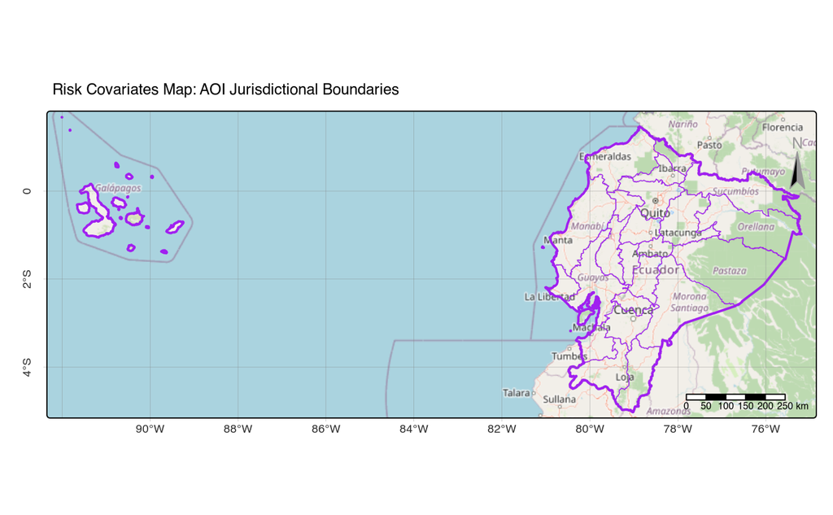

```r
crs_master = sf::st_crs(aoi_country)

# Visualize
tmap::tmap_mode("plot")
tmap::tm_shape(aoi_country) + tmap::tm_borders(col="purple", lwd=2) +
  tmap::tm_shape(aoi_states) + tmap::tm_borders(col="purple", lwd=.5) +
  tmap::tm_scalebar(position=c("RIGHT", "BOTTOM"), text.size = .5) +
  tmap::tm_compass(color.dark="gray60",text.color="gray60",position=c("RIGHT", "top")) +
  tmap::tm_graticules(lines=T,labels.rot=c(0,90),lwd=0.2) +
  tmap::tm_layout(legend.position=c("left", "top"), legend.bg.color = "white") +
  tmap::tm_title("Risk Covariates Map: AOI Jurisdictional Boundaries", size=.8) +
  tmap::tm_basemap("OpenStreetMap")
```